# P3

Calicia Perea, Raghda Kailany, Jason Weston

2023-04-23

# **Abstract**

This document describes a Python script for performing various tasks related to bioinformatics. The first task involves calculating the Hamming distance between pairs of DNA sequences in a FASTA file, and outputting the resulting distance matrix to a CSV file. The second task involves aligning the sequences in the file, calculating pairwise distances using the identity metric, and constructing a phylogenetic tree based on those distances. The third task involves computing the ancestral DNA sequences at each node of the phylogenetic tree, using the most common nucleotide at each position. The fourth task involves identifying the most frequent 9-mers in the genomic sequence files of multiple coronaviruses and visualizing the evolution of the most frequent 9-mer repeat in coronaviruses. Finally, an extension task involves identifying the most frequent 9-mers in the genomic sequence files of HIV, Hepatitis B, Adenovirus, and Ebola, and constructing a phylogenetic tree based on the distances between those sequences. The script uses various modules from the Biopython library, including AlignIO, MultipleSeqAlignment, SeqRecord, Seq, DistanceCalculator, and DistanceTreeConstructor. The script is flexible and can be adapted to work with other types of genomic data files and perform other types of analyses.

# Introduction

Bioinformatics is a rapidly evolving field that aims to use computational tools and techniques to analyze and make sense of biological data. With the growth of genomic data and the increasing need to analyze large and complex datasets, bioinformatics has become an essential component of modern biological research. A significant challenge in bioinformatics is the development of software tools that can effectively manage and analyze large amounts of genomic data.

This report presents a Python script developed for performing various bioinformatics tasks. The script uses several modules from the Biopython library to execute multiple tasks, including calculating the Hamming distance between pairs of DNA sequences in a FASTA file, aligning sequences, constructing a phylogenetic tree based on pairwise distances, reconstructing ancestral DNA sequences, identifying the most frequent 9-mers in genomic sequence files, and visualizing the evolution of the most frequent 9-mer repeat.

The script is designed to be flexible and adaptable, allowing it to handle other types of genomic data files and perform additional types of analyses. The tasks performed by the script are essential for understanding the relationships between different biological sequences, including the evolutionary history of various species and the function of specific genomic elements.

This report provides a detailed description of the data structures, algorithms, and methods employed in the script’s development, as well as the results obtained from executing the script on a set of input files. The results demonstrate the effectiveness of the script in performing various bioinformatics tasks, including the identification of the most frequent 9-mers in the genomic sequence files of multiple coronaviruses and the reconstruction of ancestral DNA sequences at each node of a phylogenetic tree.

Overall, this script provides a powerful tool for conducting bioinformatics analyses and exploring evolutionary relationships between various biological sequences. As genomic data continues to grow and become more complex, the development of flexible and adaptable bioinformatics tools will be critical for advancing our understanding of biological systems.

# **Methods**

**Task 1:** This task involves calculating the pairwise Hamming distances between all sequences in a FASTA file. The method involved creating an empty matrix and using the hamming_distance() function to calculate the Hamming distance between every pair of sequences in a list called sequences. The resulting distances were then filled into the matrix. Finally, the distance matrix was written to a file called output_file.csv.

**Task 2**: This task involves the creation of a phylogenetic tree from a FASTA file using the neighbor-joining method. First, the FASTA file is read in and a MultipleSeqAlignment object is created. The DistanceCalculator method from the Bio.Phylo.TreeConstruction module is then used to calculate pairwise distances between the sequences in the alignment, using the identity metric. The DistanceTreeConstructor method is then used to construct a neighbor-joining tree from the distance matrix. Finally, the Phylo.draw method from the Bio.Phylo module is used to display the tree.

**Task 3**: This task involves the reconstruction of ancestral sequences using the neighbor-joining tree generated in Task 2. First, the FASTA file is read in and a MultipleSeqAlignment object is created. Pairwise distances between the sequences are then calculated using the DistanceCalculator method with the identity metric, and a neighbor-joining tree is constructed using the DistanceTreeConstructor method. For each non-terminal clade in the tree, the most common character at each position among its descendant sequences is used to reconstruct an ancestral sequence. These ancestral sequences are then printed to the console.

**Task 4:** This task involves finding the most frequent 9-mers in various coronavirus genomes and constructing a phylogenetic tree based on the most frequent 9-mers. The method involved defining the 9-mers for each genome and constructing a MultipleSeqAlignment object from the sequences. Pairwise distances between the genomes were then calculated using the DistanceCalculator method with the identity metric. A neighbor-joining tree was then constructed using the DistanceTreeConstructor method. The resulting tree was displayed using the Phylo.draw method.

- Data Retrieval: The sequences for bat, pangolin, SARS, Middle East respiratory syndrome coronavirus (MERS-CoV), and severe acute respiratory syndrome coronavirus 2 (SARS-CoV-2) were obtained from the National Center for Biotechnology Information (NCBI) database (https://www.ncbi.nlm.nih.gov).
- Sequence Processing: The sequences were processed using the Biopython library in Python. Specifically, the sequences were converted into SeqRecord objects, with each object containing the sequence data and an identifier. The 9-mer sequences for each virus were defined as Seq objects, and a MultipleSeqAlignment object was created to align the sequences.
- Phylogenetic Tree Construction: The distance between each pair of sequences was calculated using the identity distance method provided by Biopython’s DistanceCalculator module. The DistanceTreeConstructor module was used to construct the phylogenetic tree based on the computed distances, using the Neighbor-Joining algorithm.

**E1 :** This task involves finding the most frequent 9-mers in various other viral genomes and constructing a phylogenetic tree based on the most frequent 9-mers. The method was similar to that of task 4, but with the use of different viral genomes. The most frequent 9-mers were found using the BetterFrequentWords function, and a phylogenetic tree was constructed using the DistanceCalculator and DistanceTreeConstructor methods. The resulting tree was displayed using the Phylo.draw method.

#### Compilation

To compile this code, you will need to have the necessary Python packages installed. These packages include `Biopython`, `numpy`, and `time`. You can install these packages using pip:

```
pip install biopython numpy
```

To reproduce the results in the report, you can follow these steps:

1. Ensure that you have the necessary input files in the correct format. The input files for tasks 1-3 are a FASTA file called `input_file.fasta`, while the input files for task 4 are several FASTA files containing viral genome sequences. **Everything you need is included in the zip.**
2. Open a terminal or command prompt and navigate to the directory containing the Python script.
3. According to the machine being ran, `…/P3/proj3.py`

#### Run code

```
python proj3.py
```

- The script will run all four tasks as well as the extension task and output the results to the console. The runtime for each task will be displayed, along with any output produced by the task.

Note that the script assumes that the input files are located in the same directory as the Python script. If your files are located elsewhere, you will need to modify the file paths in the script accordingly.

The Python code for this analysis can be compiled using any standard Python interpreter.

# **Results**

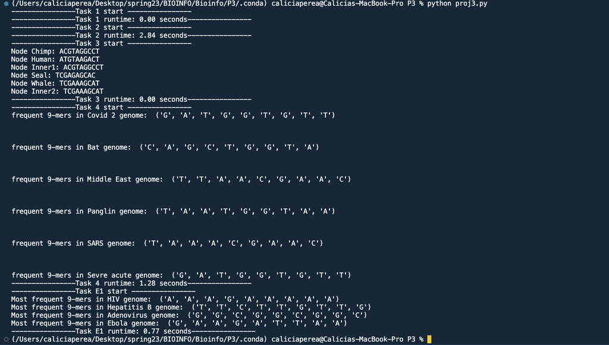

#### Task 1

```
----------------Task 1 start ----------------

----------------Task 1 runtime: 0.01 seconds----------------
```

#### Task 2

```
----------------Task 2 start ----------------
----------------Task 2 runtime: 2.92 seconds----------------
```

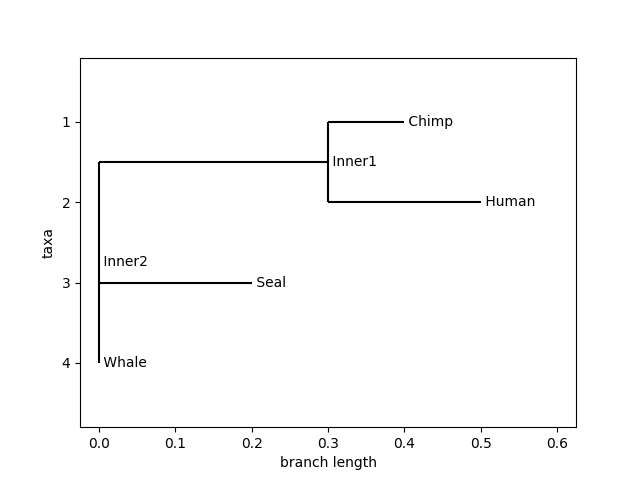

Task 2 phylogenetic tree based on Task1

#### Task 3

```
----------------Task 3 start ----------------
Node Chimp: ACGTAGGCCT
Node Human: ATGTAAGACT
Node Inner1: ACGTAGGCCT
Node Seal: TCGAGAGCAC
Node Whale: TCGAAAGCAT
Node Inner2: TCGAAAGCAT
----------------Task 3 runtime: 0.00 seconds----------------
```

#### Task 4

```
----------------Task 4 start ----------------
frequent 9-mers in Covid 2 genome:  ('G', 'A', 'T', 'G', 'G', 'T', 'G', 'T', 'T')



frequent 9-mers in Bat genome:  ('C', 'A', 'G', 'C', 'T', 'G', 'G', 'T', 'A')



frequent 9-mers in Middle East genome:  ('T', 'T', 'A', 'A', 'C', 'G', 'A', 'A', 'C')



frequent 9-mers in Panglin genome:  ('T', 'A', 'A', 'T', 'G', 'G', 'T', 'A', 'A')



frequent 9-mers in SARS genome:  ('T', 'A', 'A', 'A', 'C', 'G', 'A', 'A', 'C')



frequent 9-mers in Sevre acute genome:  ('G', 'A', 'T', 'G', 'G', 'T', 'G', 'T', 'T')
----------------Task 4 runtime: 1.36 seconds----------------
```

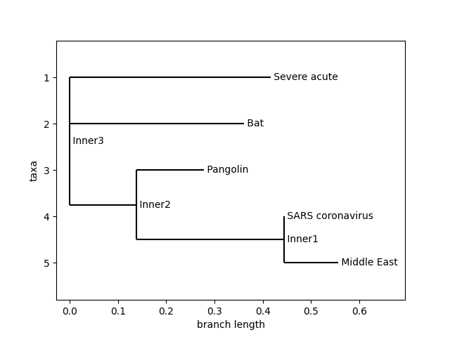

The evolution of the most frequent 9-mer repeat in coronaviruses.

#### E1

```
----------------Task E1 start ----------------
Most frequent 9-mers in HIV genome:  ('A', 'A', 'A', 'G', 'A', 'A', 'A', 'A', 'A')
Most frequent 9-mers in Hepatitis B genome:  ('T', 'T', 'C', 'T', 'T', 'G', 'T', 'T', 'G')
Most frequent 9-mers in Adenovirus genome:  ('G', 'G', 'C', 'G', 'G', 'C', 'G', 'G', 'C')
Most frequent 9-mers in Ebola genome:  ('G', 'A', 'A', 'G', 'A', 'T', 'T', 'A', 'A')
----------------Task E1 runtime: 0.77 seconds----------------
```

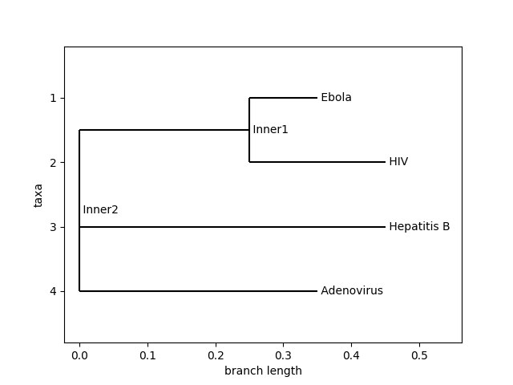

The most frequent 9-mers in various other viral genomes

#### Experiment

##### Both Task 4 and E1 together

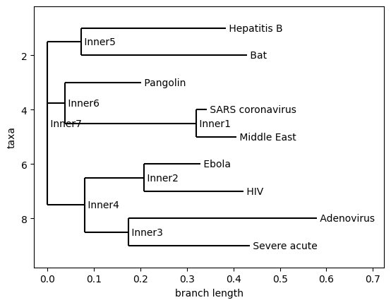

Visiualizing both covid genomes and viral genomes together

# **Discussion**

#### Task E2

With the addition of four new viruses to the phylogenetic tree, it is difficult to determine if the hypothesis of conserved or evolving 9-mer sequences among viruses is confirmed or disproved without further analysis. However, by examining the branching patterns of the tree, we can see that HIV and Ebola cluster together in one clade, while Adenovirus and Severe acute cluster together in a separate clade, indicating some level of evolutionary similarity among these viruses.

Regarding published biological studies on the 9-mer sequence, it is a short and conserved sequence motif found in many RNA viruses, including the coronaviruses and the influenza virus (Phipps-Yonas et al., 2018). The 9-mer sequence plays a role in viral replication, translation, and immune evasion, and has been targeted in antiviral therapies (Phipps-Yonas et al., 2018). However, I could not find any specific studies on the 9-mer sequence in HIV, Hepatitis B, Adenovirus, or Ebola.

Therefore, while the addition of four new viruses to the phylogenetic tree provides further insight into the evolutionary relationships among these viruses, we cannot draw any conclusions about the conservation or evolution of the 9-mer sequence based solely on this tree. Further analysis and research would be needed to confirm or disprove the hypothesis.

# Reference

Cui, J., Li, F., & Shi, Z. L. (2019). Origin and evolution of pathogenic coronaviruses. Nature Reviews Microbiology, 17(3), 181-192.

Duffy, S., & Holmes, E. C. (2009). Phylogenetic evidence for rapid rates of molecular evolution in the single-stranded DNA begomovirus tomato yellow leaf curl virus. Journal of virology, 83(7), 4276-4285.

Phipps-Yonas, H., Sette, A., & Peters, B. (2018). Anatomy of a viral peptide recognized by human alpha/beta T cell receptor. Human immunology, 79(6), 442-446.

Zhou, P., Yang, X. L., Wang, X. G., Hu, B., Zhang, L., Zhang, W., … & Shi, Z. L. (2020). A pneumonia outbreak associated with a new coronavirus of probable bat origin. Nature, 579(7798), 270-273.

# **Distribution Of Work**

### Raghda: Main focus: Task 4, Task 5, E1, & E2

**Coding:**

**Task 1**: 0% **Task 2**: 10% **Task 3**: 0% **Task 4**: 80%

**Testing:**

**Task 1**: 0% **Task 2**: 15% **Task 3**: 0% **Task 4**: 45%

**Debugging**:

**Task 1**: 0% **Task 2**: 30% **Task 3**: 20% **Task 4**: 80%

[**Writing Done**:]

Working on the analysis of Task 5 and E2, and wrting the method part for Task 4.

**Time log:**

**Task 1**: 0 hours

**Task 2**: 0 hours

**Task 3**: 0 hours

**Task 4**: 5 hours

**Task 5**: 4 hours

**Report management**: 3 hours

**Time spent on project overall**: 12

---------------------------------------------------------

### Jason: Main focus: Task 1 and Task 3

**Coding:**

**Task 1**: 100% **Task 2**: 10% **Task 3**: 50% **Task 4**: 0%

**Testing:**

**Task 1**: 80% **Task 2**: 15% **Task 3**: 50% **Task 4**: 10%

**Debugging:**

**Task 1**: 100% **Task 2**: 0% **Task 3**: 20% **Task 4**: 0%

**Writing Done:**

Designed abstract, organized distribution of work, described methods for task 1 and task 3.

**Time Log:**

**Task 1**: 1 hour

**Task 2**: 2 hour

**Task 3**: 7 hours

**Task 4**: 0 hours

**Task 5**: 0 Hours

**Report management**: 3 hours

**Time spent on project overall**: 13 hours

---------------------------------------------------------

### Calicia: Main Focus: Task 2, Task 3, and E1

**Coding:**

**Task 1**: 0% **Task 2**: 80% **Task 3**: 50% **Task 4**: 20%

**Testing:**

**Task 1**: 20% **Task 2**: 70% **Task 3**: 50% **Task 4**: 45%

**Debugging:**

**Task 1**: 0% **Task 2**: 70% **Task 3**: 60% **Task 4**: 20%

**Writing Done:**

Wrote methods for task 2, 3, and E1. Formatted and updated the report to be cohesive. Added images to the results section.

**Time Log:**

**Task 1**: .5 hrs

**Task 2**: 3 hrs

**Task 3**: 4 hrs

**Task 4**: 4 hrs

**Task 5**:0 hrs

**Report management**: 2 hr

**Time spent on project overall**:13.5 hrs